# Model comparison and information criteria

Ladislas Nalborczyk  
Univ. Grenoble Alpes, CNRS, LPNC (France) • Ghent University (Belgium)

### Null Hypothesis Significance Testing (NHST)

Let's say we are interested in height differences between women and men…

```r
men <- rnorm(100, 175, 10) # 100 men heights
women <- rnorm(100, 170, 10) # 100 women heights
```

```r
t.test(men, women)
```

```
    Welch Two Sample t-test

data:  men and women
t = 2.6635, df = 193.51, p-value = 0.008384
alternative hypothesis: true difference in means is not equal to 0
95 percent confidence interval:
 1.016738 6.818757
sample estimates:
mean of x mean of y
 174.3061  170.3884
```

### Null Hypothesis Significance Testing (NHST)

We are going to simulate t-values computed on samples generated under the assumption of no difference between women and men (the null hypothesis H0).

```r
nSims <- 1e4 # number of simulations
t <- rep(NA, nSims) # initialising an empty vector

for (i in 1:nSims) {

    men2 <- rnorm(100, 170, 10)
    women2 <- rnorm(100, 170, 10)
    t[i] <- t.test(men2, women2)$statistic

}
```

```r
t <- replicate(nSims, t.test(rnorm(100, 170, 10), rnorm(100, 170, 10) )$statistic)
```

### Null Hypothesis Significance Testing (NHST)

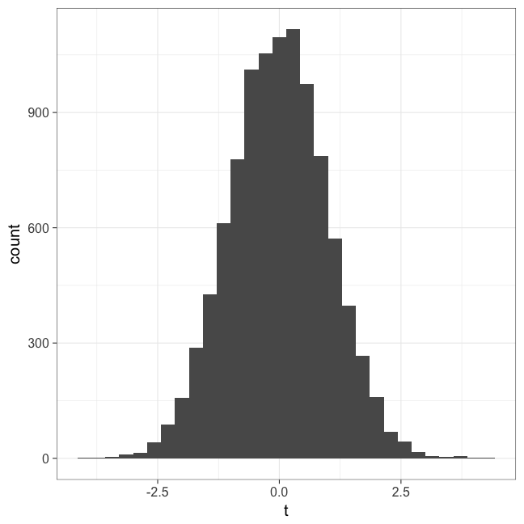

```r
data.frame(t = t) %>%
    ggplot(aes(x = t) ) +
    geom_histogram() +
    theme_bw(base_size = 20)
```

### Null Hypothesis Significance Testing (NHST)

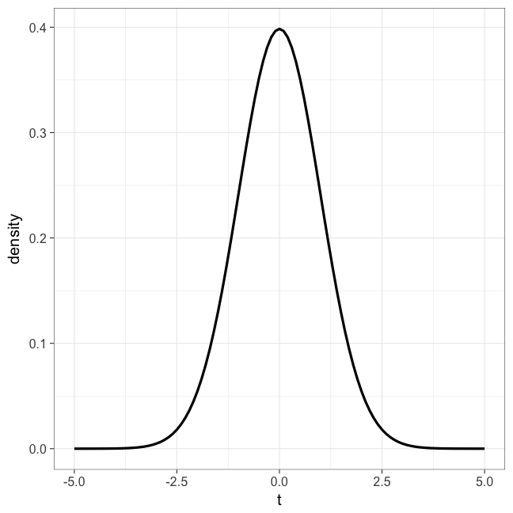

```r
data.frame(t = c(-5, 5) ) %>%
    ggplot(aes(x = t) ) +
    stat_function(fun = dt, args = list(df = t.test(men, women)$parameter), size = 1.5) +
    theme_bw(base_size = 20) + ylab("density")
```

### Null Hypothesis Significance Testing (NHST)

```r
alpha <- .05
abs(qt(alpha / 2, df = t.test(men, women)$parameter) ) # two-sided critical t-value
```

```
[1] 1.972299
```

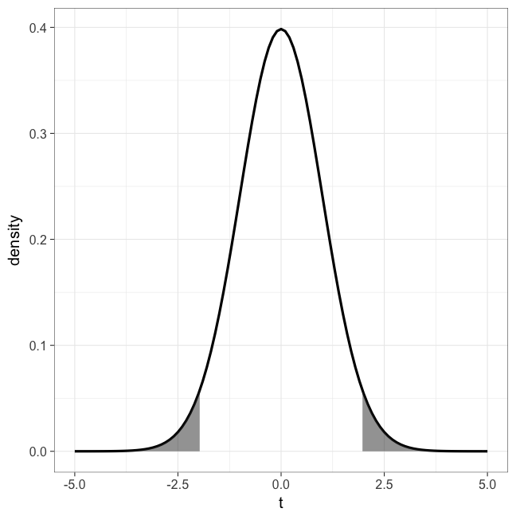

### Null Hypothesis Significance Testing (NHST)

```r
tobs <- t.test(men, women)$statistic # observed t-value
tobs %>% as.numeric
```

```
[1] 2.663544
```

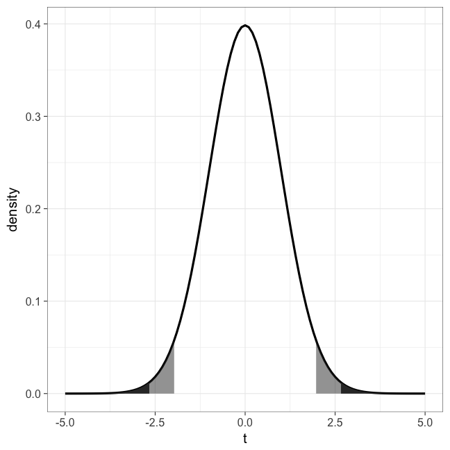

### P-values

A p-value is simply a tail area (an integral), under the distribution of test statistics under the null hypothesis. It gives the probability of observing the data we observed (or more extreme data), **given that the null hypothesis is true**.

\[ p[\mathbf{t}(\mathbf{x}^{\text{rep}}|H_{0}) \geq t(x)] \]

```r
t.test(men, women)$p.value
```

```
[1] 0.00838385
```

```r
tvalue <- abs(t.test(men, women)$statistic)
df <- t.test(men, women)$parameter

2 * integrate(dt, tvalue, Inf, df = df)$value
```

```
[1] 0.00838385
```

### Model comparison

Two common problems in statistical modelling / learning: overfitting and underfitting… how to avoid it ?

- Using regularisation. The aim is to constrain the learning, to constrain the influence of the incoming data on the inference.
- Using cross-validation or information criteria (e.g., AIC, WAIC)

\[ R^{2} = \frac{\text{var}(\text{outcome}) - \text{var}(\text{residuals})}{\text{var}(\text{outcome})} = 1 - \frac{\text{var}(\text{residuals})}{\text{var}(\text{outcome})} \]

### Overfitting

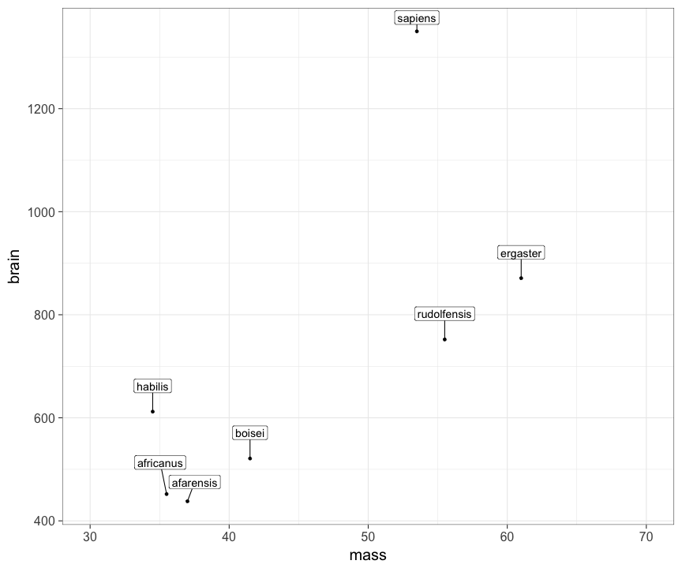

### Overfitting

```r
mod1.1 <- lm(brain ~ mass, data = d)
(var(d$brain) - var(residuals(mod1.1) ) ) / var(d$brain)
```

```
[1] 0.490158
```

```r
mod1.2 <- lm(brain ~ mass + I(mass^2), data = d)
(var(d$brain) - var(residuals(mod1.2) ) ) / var(d$brain)
```

```
[1] 0.5359967
```

```r
mod1.3 <- lm(brain ~ mass + I(mass^2) + I(mass^3), data = d)
(var(d$brain) - var(residuals(mod1.3) ) ) / var(d$brain)
```

```
[1] 0.6797736
```

### Overfitting

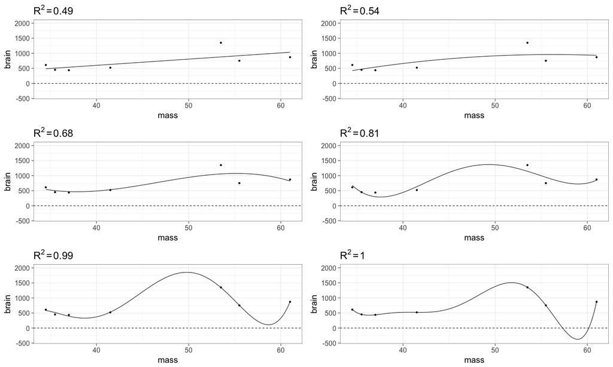

### Underfitting

\[ \begin{align} v_{i} &\sim \mathrm{Normal}(\mu_{i}, \sigma) \\ \mu_{i} &= \alpha \\ \end{align} \]

```r
mod1.7 <- lm(brain ~ 1, data = d)
```

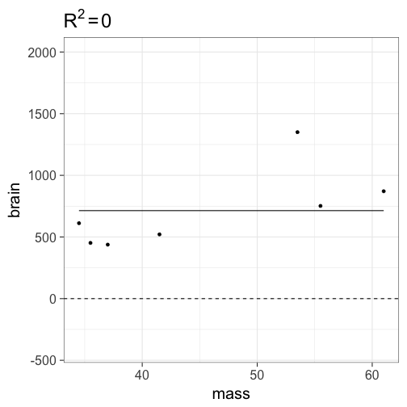

### Information theory

We would like to mesure the *distance* between our model and the *full reality* (i.e., the data generating process)… but we will first make a detour via information theory.

We can define **information** as the amount of reduction in uncertainty. When we learn a new outcome (a new observation), how much does it reduce our uncertainty ?

We need a way a measuring uncertainty. For \( n \) possible events, with each event \( i \) having a probability \( p_{i} \), a measure of uncertainty is given by:

\[ H(p) = - \text{E log}(p_{i}) = - \sum_{i=1}^{n}p_{i} \text{log}(p_{i}) \]

In other words, *the uncertainty contained in a probability distribution is the average log-probability of an event*.

### Uncertainty

Let's take as an example weather forecasting. Let's say the probability of having rain or sun on an average day in Ghent is, respectively, \( p_{1} = 0.7 \) and \( p_{2} = 0.3 \).

Then, \( H(p) = - (p_{1} \text{log}(p_{1}) + p_{2} \text{log}(p_{2}) ) \approx 0.61 \).

```r
p <- c(0.7, 0.3)
- sum(p * log(p) )
```

```
[1] 0.6108643
```

Now let's consider the weather in Abu Dabi. There, the probability of having rain or sun is of \( p_{1} = 0.01 \) and \( p_{2} = 0.99 \).

```r
p <- c(0.01, 0.99)
- sum(p * log(p) )
```

```
[1] 0.05600153
```

### Divergence

We now have a way of quantifying uncertainty. How does it help us to measure the distance between our model and the full reality ?

**Divergence**: uncertainty added by using a probability distribution to describe… another probability distribution ([Kullback-Leibler divergence](https://fr.wikipedia.org/wiki/Divergence_de_Kullback-Leibler)).

\[ D_{KL}(p,q) = \sum_{i} p_{i}\big(\text{log}(p_{i}) - \text{log}(q_{i})\big) = \sum_{i} p_{i} \text{log}\bigg(\frac{p_{i}}{q_{i}}\bigg) \]

### Divergence

\[ D_{KL}(p,q) = \sum_{i} p_{i}\big(\text{log}(p_{i}) - \text{log}(q_{i})\big) = \sum_{i} p_{i} \text{log}\bigg(\frac{p_{i}}{q_{i}}\bigg) \]

As an example, let's say that the *true* probability of the events *rain* and *sun* is \( p_{1} = 0.3 \) and \( p_{2} = 0.7 \). What uncertainty do we add if we think that the probabilities are rather \( q_{1} = 0.25 \) and \( q_{2} = 0.75 \) ?

```r
p <- c(0.3, 0.7)
q <- c(0.25, 0.75)

sum(p * log(p / q) )
```

```
[1] 0.006401457
```

```r
sum(q * log(q / p) )
```

```
[1] 0.006164264
```

### Cross entropy and Divergence

```r
sum(p * (log(q) ) )
```

The **Divergence** can be defined as the additional entropy added when using \( q \) to describe \( p \).

\[ \begin{align} D_{KL}(p,q) &= H(p,q) - H(p) \\ &= - \sum_{i} p_{i} \log(q_{i}) - \big( - \sum_{i} p_{i} \log(p_{i}) \big) \\ &= - \sum_{i} p_{i} \big(\log(q_{i}) - \log(p_{i}) \big) \\ \end{align} \]

```r
- sum (p * (log(q) - log(p) ) )
```

```
[1] 0.006401457
```

### Toward the deviance...

Fine. But we do not know the full reality in real life…

We do not need to know it ! When comparing two models (two distributions) \( q \) and \( r \), to approximate \( p \), we can compare their divergences. Thus, \( \text{E} \ \text{log}(p_{i}) \) will be the same quantity for both divergences… !

[figure not shown]

### Toward the deviance...

We can use \( \text{E} \ \text{log}(q_{i}) \) and \( \text{E} \ \text{log}(r_{i}) \) as estimations of the relative distance between each model end the target distribution (the full reality). We only need the avearge log-probability of the model.

As we do not know the target distribution, we can not interpret these values in absolute terms. We are interested in the relative distances: \( \text{E} \ \text{log}(q_{i}) - \text{E} \ \text{log}(r_{i}) \).

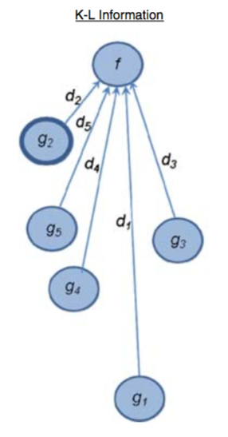

### Deviance

\[ D(q) = -2 \sum_{i} \log(q_{i}) \]

where \( i \) indexes observations and \( q_{i} \) is the *likelihood* of each observation.

```r
d$mass.s <- scale(d$mass)
mod1.8 <- lm(brain ~ mass.s, data = d)

-2 * logLik(mod1.8) # computing the deviance
```

```
'log Lik.' 94.92499 (df=3)
```

### Deviance

```r
# extracting model's coefficients

alpha <- coef(mod1.8)[1]
beta <- coef(mod1.8)[2]

# computing the log-likelihood

ll <-
    sum(
        dnorm(
            d$brain,
            mean = alpha + beta * d$mass.,
            sd = sd(residuals(mod1.8) ),
            log = TRUE
            )
        )

# computing the deviance

(-2) * ll
```

```
[1] 95.00404
```

### In-sample and out-of-sample

The deviance has the same problem as the \( R^{2} \), when it is computed on the training dataset (the observed data). In this situation, we call it **in-sample deviance**.

If we are interested in the predictive abilities of a model, we can compute the deviance of the model on a new dataset (the test dataset)… We call this the **out-of-sample deviance**. It answers the question: how bad is the model to predict future data ?

Let's say we have a sample of size \( N \), that we call the *training dataset*. We can compute the deviance of a model on this sample (\( D_{train} \) or \( D_{in} \)). If we then acquire a new sample of size \( N \) issued from the same data generating process (we call it the *test dataset*), we can compute the deviance of the model on this new dataset, by using the values of the parameters we estimated with the training dataset (we call this \( D_{test} \) or \( D_{out} \)).

### In sample and out of sample deviance

\[ \begin{align} y_{i} &\sim \mathrm{Normal}(\mu_{i},1) \\ \mu_{i} &= (0.15) x_{1,i} - (0.4) x_{2,i} \\ \end{align} \]

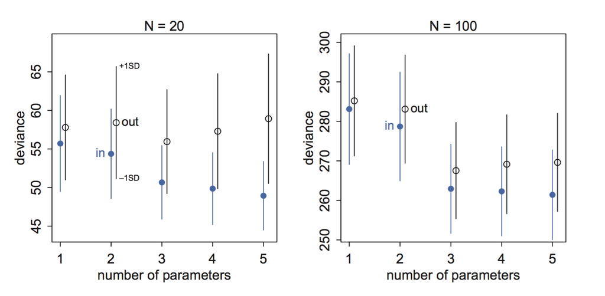

We generated data from the above model 10.000 times, and computed the in-sample and out-of-sample deviance of 5 linear models of increasing complexity.

### Regularisation

Another way to fight overfitting is to use skeptical priors that will prevent the model to learn *too much* from the data. In other words, we can use a stronger prior in order to diminish the weight of the data.

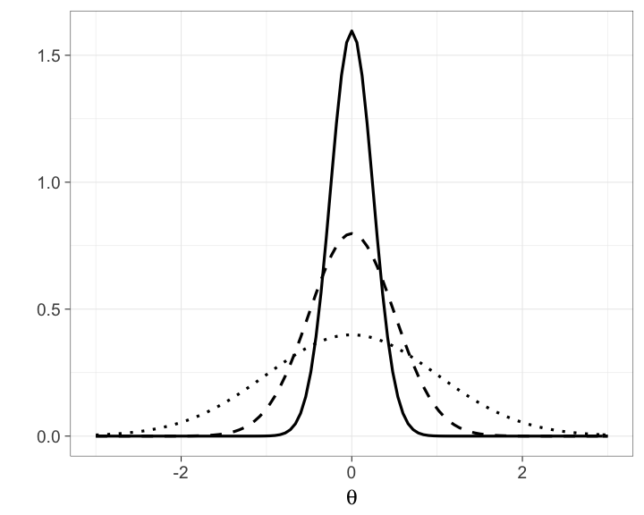

### Regularisation and cross-validation

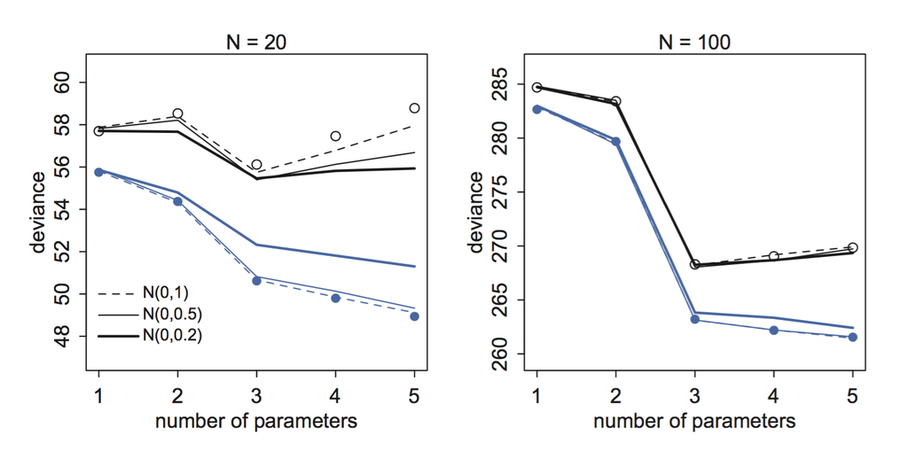

How to decide on the widht of a prior ? How to know whether a prior is *sufficiently regularising* or not ? We can divide the dataset in two parts (training and test) in order to compare different priors. We can then choose the prior that provides the lower **out-of-sample deviance**. We call this strategy **cross-validation**.

### Out-of-sample deviance and information criteria

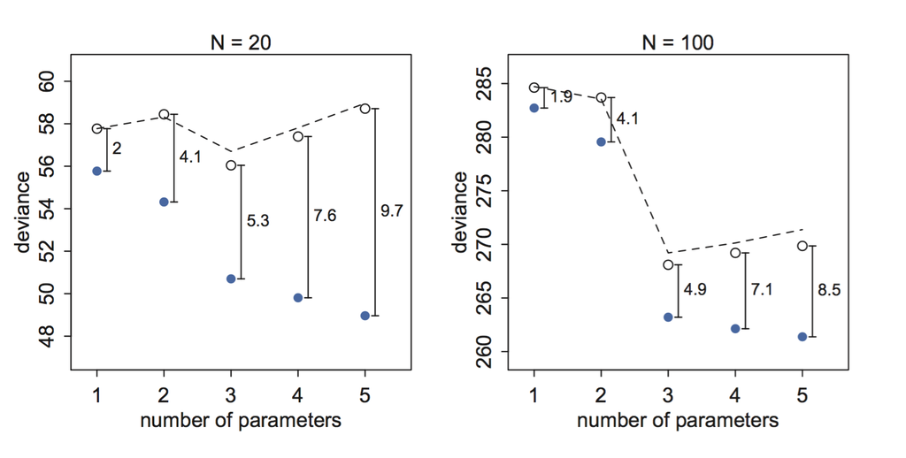

We notice that the out-of-sample deviance is approximately equal to the in-sample deviance, plus two times the number of parameters of the model…

### Akaike information criterion

The AIC offers an approximation of the **out-of-sample deviance** as:

\[ \text{AIC} = D_{train} + 2p \]

where \( p \) is the number of parameters of the model. The AIC then gives an approximation of the relative **predictive abilities** of models.

### Akaike weights and evidence ratios

The individual AIC values are not interpretable in absolute terms as they contain arbitrary constants. We usually rescale them by substracting to the AIC of each model \( i \) the AIC of the model with the minimum one:

\[ \Delta_{AIC} = AIC_{i} - AIC_{min} \]

This transformation forces the best model to have \( \Delta = 0 \), while the rest of the models have positive values. Then, the simple transformation \( exp(-\Delta_{i}/2) \) provides the likelihood of the model given the data \( \mathcal{L}(g_{i}|data) \) ([Akaike, 1981](https://www.sciencedirect.com/science/article/pii/0304407681900713)).

### Akaike weights and evidence ratios

It is convenient to normalise the model likelihoods such that they sum to 1 and that we can treat them as probabilities. Hence, we use:

\[ w_{i} = \dfrac{exp(-\Delta_{i}/2)}{\sum_{r = 1}^{R}exp(-\Delta_{r}/2)} \]

The weights \( w_{i} \) are useful as the *weight of evidence* in favour of model \( g_{i} \) as being the actual best model in the set of models, in an information-theretical sense (i.e., the closest model to the *truth*).

From there, we can compute evidence ratios (ERs) as the ratios of weights: \( ER_{ij} = \frac{w_{i}}{w_{j}} \), where \( w_{i} \) and \( w_{j} \) are the Akaike weights of models \( i \) and \( j \), respectively.

### Akaike weights and evidence ratios

We want to predict how many kilo calories per gram of milk (`kcal.per.g`) different species do have, as a function of neocortex volume and body mass. We can fit a few models and compare them using the AIC.

```r
library(rethinking)
data(milk)

d <-
    milk %>%
    na.omit %>%
    mutate(neocortex = neocortex.perc / 100) %>%
    select(species, kcal.per.g, mass, neocortex)

head(d, 10)
```

```
               species kcal.per.g mass neocortex
1       Eulemur fulvus       0.49 1.95    0.5516
2   Alouatta seniculus       0.47 5.25    0.6454
3           A palliata       0.56 5.37    0.6454
4         Cebus apella       0.89 2.51    0.6764
5           S sciureus       0.92 0.68    0.6885
6     Cebuella pygmaea       0.80 0.12    0.5885
7    Callimico goeldii       0.46 0.47    0.6169
8   Callithrix jacchus       0.71 0.32    0.6032
9  Miopithecus talpoin       0.68 1.55    0.6997
10           M mulatta       0.97 3.24    0.7041
```

### Akaike weights and evidence ratios

```r
m1 <- lm(kcal.per.g ~ 1, data = d, na.action = na.fail)
m2 <- lm(kcal.per.g ~ 1 + neocortex, data = d, na.action = na.fail)
m3 <- lm(kcal.per.g ~ 1 + log(mass), data = d, na.action = na.fail)
m4 <- lm(kcal.per.g ~ 1 + neocortex + log(mass), data = d, na.action = na.fail)
```

```r
library(MuMIn) # package for MultiModel Inference

(ictab <- model.sel(list(m1 = m1, m2 = m2, m3 = m3, m4 = m4) ) )
```

```
Model selection table
     (Int)    ncr log(mss) df logLik  AICc delta weight
m4 -1.0850 2.7930 -0.09640  4 12.678 -14.0  0.00  0.926
m1  0.6576                  2  6.229  -7.6  6.42  0.037
m3  0.7052        -0.03169  3  7.369  -6.9  7.13  0.026
m2  0.3533 0.4503           3  6.437  -5.0  8.99  0.010
Models ranked by AICc(x)
```

### Model averaging

We could select the best model and base our inference on this model only. But this strategy would ignore the uncertainty in model selection (i.e., that the best is only probably the best model). Another strategy would be to construct averaged predictions, where the predictions of each model are weighted by the relative predictive abilities of the model, expressed by its Akaike weight…

```r
(mavg <- model.avg(ictab) )
```

```
Call:
model.avg(object = ictab)

Component models:
'12'     '(Null)' '2'      '1'

Coefficients:
       (Intercept) neocortex   log(mass)
full    -0.9583815  2.591357 -0.09011028
subset  -0.9583815  2.767250 -0.09462151
```

### Model averaging

We can then plot the predictions of each model and the averaged predictions (in black, along with its 95% CIs), according to `neocortex` and for an average value of `mass`.

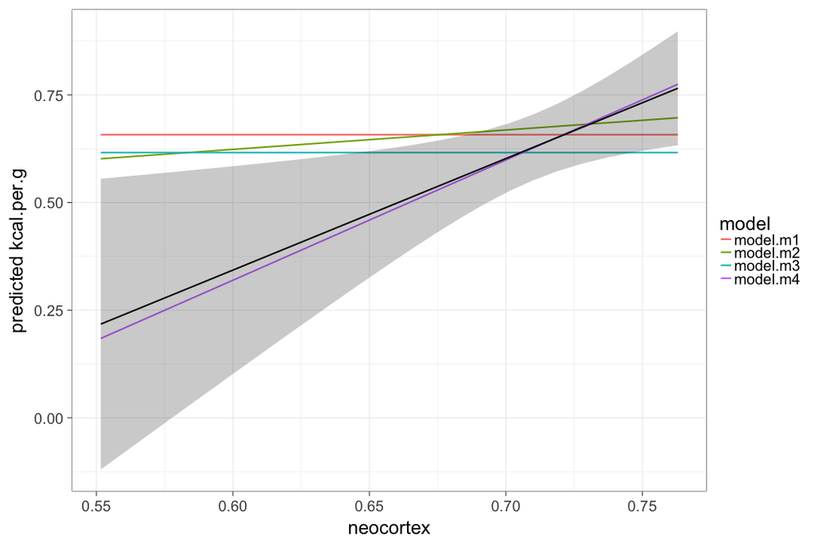

### Practice - 1/3

Using the `attitude` dataset explored previously.

```r
data <- read.csv("attitude.csv")
head(data, 10)
```

```
   participant    sex drink  imagery ratings
1            1 female  beer negative       6
2            2 female  beer negative      30
3            3 female  beer negative      15
4            4 female  beer negative      30
5            5 female  beer negative      12
6            6 female  beer negative      17
7            7 female  beer negative      21
8            8 female  beer negative      23
9            9 female  beer negative      20
10          10 female  beer negative      27
```

### Practice - 2/3

Build the following linear models, using the `lm` function.

\[ \begin{align} \mathcal{M_{1}} : \text{ratings}_{i} &\sim \mathrm{Normal}(\mu_{i},\sigma) \\ \mu_{i} &= \alpha + \beta_{1} \text{sex}_{i} \\ \mathcal{M_{2}} : \text{ratings}_{i} &\sim \mathrm{Normal}(\mu_{i},\sigma) \\ \mu_{i} &= \alpha + \beta_{1} \text{drink}_{i} \\ \mathcal{M_{3}} : \text{ratings}_{i} &\sim \mathrm{Normal}(\mu_{i},\sigma) \\ \mu_{i} &= \alpha + \beta_{1} \text{drink}_{i} + \beta_{2} \text{imagery}_{i} + \beta_{3} \text{drink}_{i} \times \text{imagery}_{i} \\ \mathcal{M_{4}} : \text{ratings}_{i} &\sim \mathrm{Normal}(\mu_{i},\sigma) \\ \mu_{i} &= \alpha + \beta_{1} \text{sex}_{i} + \beta_{2} \text{drink}_{i} + \beta_{3} \text{imagery}_{i} + \beta_{4} \text{drink}_{i} \times \text{imagery}_{i} \\ \mathcal{M_{5}} : \text{ratings}_{i} &\sim \mathrm{Normal}(\mu_{i},\sigma) \\ \mu_{i} &= \alpha + \beta_{1} \text{sex}_{i} + \beta_{2} \text{drink}_{i} + \beta_{3} \text{imagery}_{i} \\ \end{align} \]

### Practice - 3/3

1. Compare these models using the AIC. Compare the ranks and the weights of the models.
2. For each model, plot the estimated mean and 90% confidence interval of the mean, overlaid on the raw data. How the predictions differ across the models ?
3. Make a plot of the averaged predictions (averaged on the three best models). How these averaged predictions differ from the predictions of the best model (i.e., the model with the lowest AIC) ?

### Solution - question 1

```r
m1 <- lm(ratings ~ sex, data)
m2 <- lm(ratings ~ drink, data)
m3 <- lm(ratings ~ drink + imagery + drink:imagery, data)
m4 <- lm(ratings ~ sex + drink + imagery + drink:imagery, data)
m5 <- lm(ratings ~ sex + drink + imagery, data)

(ictab <- model.sel(list(m1 = m1, m2 = m2, m3 = m3, m4 = m4, m5 = m5) ) )
```

```
Model selection table
   (Int) sex drn img drn:img df   logLik  AICc delta weight
m5 7.325   +   +   +          5 -298.315 607.4  0.00  0.567
m4 8.825   +   +   +       +  6 -297.418 608.0  0.55  0.432
m3 4.450       +   +       +  5 -304.472 619.8 12.32  0.001
m2 7.225       +              3 -310.868 628.1 20.61  0.000
m1 6.275   +                  3 -313.437 633.2 25.75  0.000
Models ranked by AICc(x)
```

### Solution - question 2

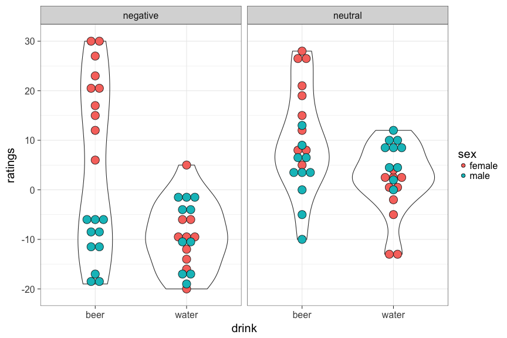

```r
data %>%
    ggplot(aes(x = drink, fill = sex, y = ratings) ) +
    geom_violin(
        aes(x = drink, group = drink, colour = sex, fill = sex, y = ratings),
        alpha = 0.5, show.legend = FALSE
        ) +
    geom_dotplot(binaxis = "y", stackdir = "center") +
    facet_wrap(~imagery) + theme_bw(base_size = 20)
```

### Solution - question 3

[figure not shown]

```r
data %>%
    ggplot(aes(x = drink, fill = sex, y = ratings) ) +
    geom_violin(
        aes(x = drink, group = drink, colour = sex, fill = sex, y = ratings),
        alpha = 0.5, show.legend = FALSE
        ) +
    geom_dotplot(binaxis = "y", stackdir = "center") +
    facet_wrap(~imagery) + theme_bw(base_size = 20)
```